# Lab 2: Spatial Analysis and Visualization

Healthcare Access and Equity in Pennsylvania

Author

Alejandro Duque

Published

February 23, 2026

## Assignment Overview

**Learning Objectives:** - Apply spatial operations to answer policy-relevant research questions - Integrate census demographic data with spatial analysis - Create publication-quality visualizations and maps - Work with spatial data from multiple sources - Communicate findings effectively for policy audiences

## Part 1: Healthcare Access for Vulnerable Populations

### Research Question

**Which Pennsylvania counties have the highest proportion of vulnerable populations (elderly + low-income) living far from hospitals?**

Your analysis should identify counties that should be priorities for healthcare investment and policy intervention.

### Required Analysis Steps

Complete the following analysis, documenting each step with code and brief explanations:

#### Step 1: Data Collection (5 points)

Load the required spatial data: - Pennsylvania county boundaries - Pennsylvania hospitals (from lecture data) - Pennsylvania census tracts

**Your Task:**

```r
echo=FALSE

# Load required packages

library(tidycensus)
library(tidyverse)
library(knitr)
library(sf)
library(tigris)
library(units)
library(tmap)
library(ggplot2)
library(dplyr)
library(scales)

# Load spatial data
pa_hospitals <- st_read("data/hospitals.geojson")
pa_counties <- st_read("data/Pennsylvania_County_Boundaries.shp")
pa_tracts <- tracts(state = "PA", cb = TRUE, year = 2024)

# Check that all data loaded correctly
summary(pa_hospitals)
summary(pa_counties)
summary(pa_tracts)

st_crs(pa_hospitals)
st_crs(pa_tracts)
st_crs(pa_counties)
```

**Questions to answer:** - How many hospitals are in your dataset? There are 223 hospitals in the dataset

- How many census tracts? There are 3445 census tracts in PA
- What coordinate reference system is each dataset in? pa_hospitals is in WGS84, pa_tracts is in NAD83, and pa_counties is also in WGS84

#### Step 2: Get Demographic Data

Use `tidycensus` to download tract-level demographic data for Pennsylvania.

**Required variables:** - Total population - Median household income - Population 65 years and over (you may need to sum multiple age categories)

**Your Task:**

```r
# Get demographic data from ACS

v24 <- load_variables(2024, "acs5", cache = TRUE)


acs2024 <- c(totpop = "B01003_001",
             medincome = "B19013_001",
             total_hh = "B11001_001",
             pop_65plus = "B09020_001")

pa_data <- get_acs(geography = "tract",
                   state = "PA",
                   variables = acs2024,
                   survey = "acs5",
                   year = 2024,
                   output = "wide")

# Join to tract boundaries
pa_tracts_joined <- pa_tracts %>%
  left_join(pa_data, by = "GEOID")

sum(is.na(pa_tracts_joined$medincomeE))
median(pa_tracts_joined$medincomeE, na.rm = TRUE)
```

**Questions to answer:** - What year of ACS data are you using? I am using the ACS 2024 data

- How many tracts have missing income data? 68 tracts have missing income data
- What is the median income across all PA census tracts? Median income across all PA census tracts is $74,844

#### Step 3: Define Vulnerable Populations

Identify census tracts with vulnerable populations based on TWO criteria: 1. Low median household income (choose an appropriate threshold) 2. Significant elderly population (choose an appropriate threshold)

**Your Task:**

```r
# Filter for vulnerable tracts based on your criteria

pa_tracts_joined <- pa_tracts_joined %>%
  mutate(pct_65plus = round((pop_65plusE/totpopE) * 100, 2))

pa_tracts_vulnerable <- pa_tracts_joined %>%
  filter(
    medincomeE < 70000,
    pct_65plus >= 30
  )
```

**Questions to answer:** - What income threshold did you choose and why? I chose an income threshold of 70,000 dollars because for a family of 2 (the average PA family size) that is beyond the poverty threshold for PA, but still about 5,000 dollars under the median income of the state.

- What elderly population threshold did you choose and why? I originally chose 40% as the threshold because that meant that the elderly population would account for more than a third of the population, but then no census tracts met the criteria and so I assigned the threshold as 30% which still has significance if you split the population into 4 categories (school aged, working age, middle age, elderly) since 30% is a plurality among the categories.
- How many tracts meet your vulnerability criteria? 92 tracts
- What percentage of PA census tracts are considered vulnerable by your definition? 2.67%, almost three percent

#### Step 4: Calculate Distance to Hospitals

For each vulnerable tract, calculate the distance to the nearest hospital.

**Your Task:**

```r
# Transform to appropriate projected CRS
pa_tracts_vulnerable <- st_transform(pa_tracts_vulnerable, crs = 2272)
pa_hospitals <- st_transform(pa_hospitals, crs = 2272)

# Calculate distance from each tract centroid to nearest hospital
tracts_vulnerable_centroid <- pa_tracts_vulnerable %>%
  st_centroid(pa_tracts_vulnerable)

dist_hospitals <- st_distance(tracts_vulnerable_centroid, pa_hospitals)

pa_tracts_vulnerable <- pa_tracts_vulnerable %>%
  mutate(
    dist_hosp_ft = apply(dist_hospitals, 1, min),
    dist_hosp_miles = dist_hosp_ft / 5280,
    nearest_hosp = apply(dist_hospitals, 1, which.min),
    nearest_hosp_name = pa_hospitals$FACILITY_N[nearest_hosp],
    underserved = dist_hosp_miles > 15 & medincomeE < 70000
  )

mean(pa_tracts_vulnerable$dist_hosp_miles, na.rm = TRUE)
max(pa_tracts_vulnerable$dist_hosp_miles, na.rm = TRUE)

sum(pa_tracts_vulnerable$dist_hosp_miles > 15,  na.rm = TRUE)
```

**Requirements:** - Use an appropriate projected coordinate system for Pennsylvania - Calculate distances in miles - Explain why you chose your projection

- What is the maximum distance? The maximum distance from a hospital is 19.86 miles.
- How many vulnerable tracts are more than 15 miles from the nearest hospital? Eight census tracts

#### Step 5: Identify Underserved Areas

Define “underserved” as vulnerable tracts that are more than 15 miles from the nearest hospital.

**Your Task:**

```r
# Create underserved variable

underserved_tracts <- pa_tracts_vulnerable %>%
  filter(pa_tracts_vulnerable$dist_hosp_miles > 15)
```

**Questions to answer:** - How many tracts are underserved? 8 tracts are underserved

- What percentage of vulnerable tracts are underserved? about 9% of vulnerable tracts are underserved
- Does this surprise you? Why or why not? It is actually surprising to me that only 8 out of 92 vulnerable census tracts are more than 15 miles from a hospital. I suspected that rural census tracts would more frequently fall under the vulnerable definition

#### Step 6: Aggregate to County Level

Use spatial joins and aggregation to calculate county-level statistics about vulnerable populations and hospital access.

**Your Task:**

```r
# Spatial join tracts to counties
st_crs(pa_counties)
pa_counties <- st_transform(pa_counties, crs = 2272)

pa_counties <- rename(pa_counties, COUNTYFP = FIPS_COUNT)

pa_tracts_vulnerable <- pa_tracts_vulnerable %>%
  left_join(
    pa_counties %>% st_drop_geometry(),
    by = "COUNTYFP"
    )

# Aggregate statistics by county

county_summary <- pa_tracts_vulnerable %>%
  st_drop_geometry() %>%
  group_by(COUNTYFP, COUNTY_NAM) %>%
  summarise(
    # Tracts
    total_tracts = n(),
    tracts_far = sum(dist_hosp_miles > 15, na.rm = TRUE),
    pct_tracts_far = (tracts_far/total_tracts) * 100,
    n_underserved = sum(underserved, na.rm = TRUE),
    pct_underserved = (n_underserved / total_tracts) * 100,
    # Population
    total_pop = sum(totpopE, na.rm = TRUE),
    total_elderly = sum(pop_65plusE, na.rm = TRUE),
    pct_elderly = (total_elderly/total_pop) * 100,
    # Income
    total_hh = sum(total_hhE, na.rm = TRUE),
    avg_medincome = mean(medincomeE, na.rm = TRUE),
    low_income = sum(medincomeE < 70000, na.rm = TRUE),
    pct_low_income = (low_income/total_hh) * 100,
    # Distance to Hospital
    mean_dist = mean(dist_hosp_miles, na.rm = TRUE),

    .groups = "drop"
  )
```

**Required county-level statistics:** - Number of vulnerable tracts - Number of underserved tracts  
- Percentage of vulnerable tracts that are underserved - Average distance to nearest hospital for vulnerable tracts - Total vulnerable population

**Questions to answer:** - Which 5 counties have the highest percentage of underserved vulnerable tracts? Sullivan county is the only county that has two census tracts that meet the underserved definition. There were then 6 other counties with just one underserved census tract. Those counties are the following: Cameron, Clearfield, Forest, Pike, Potter, Wayne.

- Which counties have the most vulnerable people living far from hospitals? Sullivan county has the most (with two), but the counties with the most vulnerable poeple living far from a hospital is the same hospitals that also fall under the underserved definition
- Are there any patterns in where underserved counties are located? Most or all of those counties are in rural areas, which is expected from what we expect about communities without hospital access.

#### Step 7: Create Summary Table

Create a professional table showing the top 10 priority counties for healthcare investment.

**Your Task:**

```r
# Create and format priority counties table
library(knitr)
library(kableExtra)

top7_counties <- county_summary %>%
  arrange(desc(n_underserved)) %>%
  head(7) %>%
  select(
    County = COUNTY_NAM,
    `Total Vulnerable Tracts` = total_tracts,
    `Total Underserved Tracts` = n_underserved,
    `Average Dist. to Hospital` = mean_dist
  ) %>%
  mutate(
    `Average Dist. to Hospital` = round(`Average Dist. to Hospital`, 1)
  )

#Kable Chart
top7_counties %>%
  kbl(
    caption  = "Top 7 Pennsylvania Counties Prioritized for Healthcare Investment",
    align    = c("l", "r", "r", "r"),
    booktabs = TRUE
  ) %>%
  kable_styling(
    bootstrap_options = c("striped", "hover", "condensed"),
    full_width        = FALSE,
    position          = "center",
    font_size         = 13
  ) %>%
  row_spec(0, bold = TRUE, background = "#2c3e50", color = "white") %>%
  row_spec(1, bold = TRUE, background = "#fff3cd") %>%
  column_spec(1, bold = TRUE) %>%
  column_spec(4,
    color      = "white",
    background = spec_color(top7_counties$`Average Dist. to Hospital`,
                            option = "C",
                            begin  = 0.4,
                            end    = 0.9)
  ) %>%
  footnote(
    general = "Source: ACS 2022 5-year estimates. PA DOH Hospital Data.",
    number  = c(
      "Total Vulnerable Tracts = all tracts within county",
      "Total Underserved Tracts = tracts > 15 miles from hospital AND median income < $70,000",
      "Average Dist. to Hospital = mean straight-line distance in miles from tract centroid to nearest hospital"
    )
  )
```

[output not shown]

**Requirements:** - Use `knitr::kable()` or similar for formatting - Include descriptive column names - Format numbers appropriately (commas for population, percentages, etc.) - Add an informative caption - Sort by priority (you decide the metric)

## Part 2: Comprehensive Visualization

Using the skills from Week 3 (Data Visualization), create publication-quality maps and charts.

### Map 1: County-Level Choropleth

Create a choropleth map showing healthcare access challenges at the county level.

**Your Task:**

[figure not shown]

```r
# Create county-level access map
library(ggplot2)
library(sf)
library(dplyr)
library(scales)

pa_counties_map <- pa_counties %>%
  left_join(
    county_summary %>% select(COUNTYFP, pct_underserved, n_underserved),
    by = "COUNTYFP"
  )

top7_labels <- pa_counties_map %>%
  arrange(desc(pct_underserved)) %>%
  head(7) %>%
  st_centroid()

ggplot() +

  geom_sf(
    data      = pa_counties_map,
    aes(fill  = pct_underserved),
    color     = "white",
    linewidth = 0.4
  ) +

  scale_fill_gradientn(
    colors   = c("#fee5d9", "#fcae91", "#fb6a4a", "#de2d26", "#a50f15"),
    name     = "% Underserved\nVulnerable Tracts",
    na.value = "grey85",
    labels   = function(x) paste0(round(x, 1), "%"),
    guide    = guide_colorbar(
      barwidth    = 1,
      barheight   = 8,
      title.hjust = 0.5,
      ticks       = TRUE,
      frame.colour = "grey40"
    )
  ) +

  geom_sf(
    data  = pa_hospitals,
    shape = 1,
    size  = 1.2,
    color = "black",
    alpha = 0.5,
    stroke = 0.4
  ) +

  geom_sf_text(
    data     = top7_labels,
    aes(label = COUNTY_NAM),
    size     = 2.6,
    fontface = "bold",
    color    = "black",
    check_overlap = TRUE
  ) +

  # Titles and caption
  labs(
    title    = "Pennsylvania Healthcare Access: Underserved Populations",
    subtitle = "Counties shaded have vulnerable census tracts, and counties that are named have tracts that are considered underserved\nmeaning they both > 15 miles from a hospital and have median household income below $70,000",
    caption  = "Sources: U.S. Census ACS 2022 5-Year Estimates and PA Department of Health\nHospital locations shown as (o) symbols · Underserved = far from hospital AND low income"
  ) +

  theme_void(base_size = 12) +
  theme(
    plot.title    = element_text(
      face   = "bold",
      size   = 15,
      hjust  = 0.5,
      margin = margin(b = 5)
    ),
    plot.subtitle = element_text(
      size   = 9,
      hjust  = 0.5,
      color  = "grey35",
      lineheight = 1.4,
      margin = margin(b = 12)
    ),
    plot.caption  = element_text(
      size   = 7.5,
      hjust  = 0.5,
      color  = "grey50",
      lineheight = 1.4,
      margin = margin(t = 10)
    ),
    legend.position  = "right",
    legend.title     = element_text(size = 8.5, face = "bold", hjust = 0.5),
    legend.text      = element_text(size = 8),
    plot.margin      = margin(20, 20, 20, 20),
    plot.background  = element_rect(fill = "white", color = NA)
  )
```

```r
ggsave(
  filename = "map1_county_choropleth.png",
  width    = 11,
  height   = 7,
  dpi      = 300,
  bg       = "white"
)
```

**Requirements:** - Fill counties by percentage of vulnerable tracts that are underserved - Include hospital locations as points - Use an appropriate color scheme - Include clear title, subtitle, and caption - Use `theme_void()` or similar clean theme - Add a legend with formatted labels

### Map 2: Detailed Vulnerability Map

Create a map highlighting underserved vulnerable tracts.

**Your Task:**

[figure not shown]

```r
# Create detailed tract-level map
pa_tracts_vulnerable <- pa_tracts_vulnerable %>%
  mutate(
    tract_category = case_when(
      dist_hosp_miles > 15 & medincomeE < 70000 ~ "Underserved Vulnerable",
      dist_hosp_miles > 15 ~ "Far from Hospital Only",
      medincomeE < 70000 ~ "Low Income Only",
      TRUE ~ "Not Underserved"
    )
  )

pa_tracts_vulnerable <- pa_tracts_vulnerable %>%
  mutate(tract_category = factor(tract_category, levels =
                                   c("Underserved Vulnerable",
                                     "Far from Hospital Only",
                                     "Low Income Only",
                                     "Not Underserved")))
ggplot() +
    geom_sf(
    data      = pa_tracts_vulnerable,
    aes(fill  = tract_category),
    color     = NA,
    alpha     = 0.85
  ) +
    geom_sf(
    data      = pa_counties,
    fill      = NA,
    color     = "grey20",
    linewidth = 0.5
  ) +
   geom_sf(
    data   = pa_hospitals,
    shape  = 1,                          # open circle
    size   = 1.5,
    color  = "black",
    stroke = 0.5,
    alpha  = 0.7
  ) +
 scale_fill_manual(
    values = c(
      "Underserved Vulnerable" = "#a50f15",
      "Far from Hospital Only" = "#fc8d59",
      "Low Income Only"        = "#fdcc8a",
      "Not Underserved"        = "#f7f7f7"),
    name = "Tract Category"
  ) +
  labs(
    title    = "Underserved Vulnerable Census Tracts in Pennsylvania",
    subtitle = "Tracts classified by hospital distance (> 15 miles) and household income (< $70,000)\nCounty boundaries shown and Hospital locations marked as open circles",
    caption  = "Sources: U.S. Census ACS 2022 5-Year Estimates and PA Department of Health\nUnderserved Vulnerable = tract is BOTH far from a hospital AND low income"
  ) +
  theme_void(base_size = 12) +
  theme(
    plot.title     = element_text(face = "bold", size = 15, hjust = 0.5, margin = margin(b = 5)),
    plot.subtitle  = element_text(size = 9, hjust = 0.5, color = "grey35",
                                  lineheight = 1.4, margin = margin(b = 10)),
    plot.caption   = element_text(size = 7.5, hjust = 0.5, color = "grey50",
                                  lineheight = 1.4, margin = margin(t = 10)),
    legend.position  = "right",
    legend.title     = element_text(size = 9, face = "bold"),
    legend.text      = element_text(size = 8.5),
    legend.key.size  = unit(0.5, "cm"),
    legend.spacing.y = unit(0.3, "cm"),
    plot.margin      = margin(20, 20, 20, 20),
    plot.background  = element_rect(fill = "white", color = NA)
  )
```

**Requirements:** - Show underserved vulnerable tracts in a contrasting color - Include county boundaries for context - Show hospital locations - Use appropriate visual hierarchy (what should stand out?) - Include informative title and subtitle

### Chart: Distribution Analysis

Create a visualization showing the distribution of distances to hospitals for vulnerable populations.

**Your Task:**

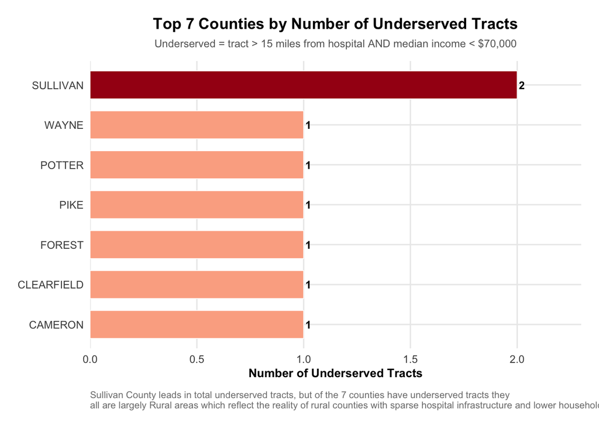

```r
# Create distribution visualization
base_theme <- theme_minimal(base_size = 12) +
  theme(
    plot.title = element_text
    (face = "bold", size = 13, hjust = 0.5),

    plot.subtitle = element_text
    (size = 9, hjust = 0.5, color = "grey40", margin = margin(b = 10)),

     plot.caption = element_text
    (size = 8, hjust = 0, color = "grey50", margin = margin(t = 10)),

    axis.title = element_text(size = 10, face = "bold"),
    axis.text = element_text(size = 9),
    panel.grid.minor = element_blank(),
    plot.background = element_rect(fill = "white", color = NA),
    plot.margin = margin(15, 15, 15, 15)
    )


plot1 <- county_summary %>%
  arrange(desc(n_underserved)) %>%
  head(7) %>%
  mutate(COUNTY_NAM = reorder(COUNTY_NAM, n_underserved)) %>%

  ggplot(aes(x = COUNTY_NAM, y = n_underserved, fill = n_underserved)) +
  geom_col(
    width = 0.7,
    color = "white",
    linewidth = 0.3
  ) +
  geom_text(
    aes(label = n_underserved),
    hjust  = -0.3,
    size   = 3.2,
    fontface = "bold"
  ) +
  scale_fill_gradientn(
    colors = c("#fcae91", "#fb6a4a", "#de2d26", "#a50f15"),
    guide  = "none"
  ) +
  scale_y_continuous(
    expand = expansion(mult = c(0, 0.15))
  ) +
  coord_flip() +
  labs(
    title = "Top 7 Counties by Number of Underserved Tracts",
    subtitle = "Underserved = tract > 15 miles from hospital AND median income < $70,000",
    x = NULL,
    y = "Number of Underserved Tracts",
    caption = "Sullivan County leads in total underserved tracts, but of the 7 counties have underserved tracts they\nall are largely Rural areas which reflect the reality of rural counties with sparse hospital infrastructure and lower household incomes."
  ) +
  base_theme

print(plot1)
```

**Suggested chart types:** - Histogram or density plot of distances - Box plot comparing distances across regions - Bar chart of underserved tracts by county - Scatter plot of distance vs. vulnerable population size

**Requirements:** - Clear axes labels with units - Appropriate title - Professional formatting - Brief interpretation (1-2 sentences as a caption or in text)

## Part 3: Bring Your Own Data Analysis

Choose your own additional spatial dataset and conduct a supplementary analysis.

### Challenge Options

Choose ONE of the following challenge exercises, or propose your own research question using OpenDataPhilly data (https://opendataphilly.org/datasets/).

#### Environmental Justice

**Option C: Green Space Equity** - **Data:** Parks, Street Trees, Census tracts (race/income demographics) - **Question:** “Do low-income and minority neighborhoods have equitable access to green space?” - **Operations:** Buffer parks (10-minute walk = 0.5 mile), calculate tree canopy or park acreage per capita, compare by demographics - **Policy relevance:** Climate resilience, environmental justice, urban forestry investment —

### Data Sources

**OpenDataPhilly:** https://opendataphilly.org/datasets/ - Most datasets available as GeoJSON, Shapefile, or CSV with coordinates - Always check the Metadata for a data dictionary of the fields.

**Additional Sources:** - **Pennsylvania Open Data:** https://data.pa.gov/ - **Census Bureau (via tidycensus):** Demographics, economic indicators, commute patterns - **TIGER/Line (via tigris):** Geographic boundaries

### Your Analysis

**Your Task:**

1. **Find and load additional data**
   - Document your data source
   - Check and standardize the CRS
   - Provide basic summary statistics

```r
# Load your additional dataset
#| message: FALSE
#| warning: FALSE
#| results: 'hide'


acs2024_1 <- c(totpop = "B01003_001",
             medincome = "B19013_001",
             total_hh = "B11001_001",
             pct_poverty = "S1701_C03_001"
             )

philly_data <- get_acs(geography = "tract",
                   state = "PA",
                   county = "Philadelphia",
                   variables = acs2024_1,
                   survey = "acs5",
                   year = 2024,
                   output = "wide",
                   geometry = TRUE)

philly_trees <- st_read("data/ppr_tree_canopy_outlines_2015.geojson")
st_crs(philly_data)
```

```
Coordinate Reference System:
  User input: NAD83
  wkt:
GEOGCRS["NAD83",
    DATUM["North American Datum 1983",
        ELLIPSOID["GRS 1980",6378137,298.257222101,
            LENGTHUNIT["metre",1]]],
    PRIMEM["Greenwich",0,
        ANGLEUNIT["degree",0.0174532925199433]],
    CS[ellipsoidal,2],
        AXIS["latitude",north,
            ORDER[1],
            ANGLEUNIT["degree",0.0174532925199433]],
        AXIS["longitude",east,
            ORDER[2],
            ANGLEUNIT["degree",0.0174532925199433]],
    ID["EPSG",4269]]
```

```r
st_crs(philly_trees)
```

```
Coordinate Reference System:
  User input: WGS 84
  wkt:
GEOGCRS["WGS 84",
    DATUM["World Geodetic System 1984",
        ELLIPSOID["WGS 84",6378137,298.257223563,
            LENGTHUNIT["metre",1]]],
    PRIMEM["Greenwich",0,
        ANGLEUNIT["degree",0.0174532925199433]],
    CS[ellipsoidal,2],
        AXIS["geodetic latitude (Lat)",north,
            ORDER[1],
            ANGLEUNIT["degree",0.0174532925199433]],
        AXIS["geodetic longitude (Lon)",east,
            ORDER[2],
            ANGLEUNIT["degree",0.0174532925199433]],
    ID["EPSG",4326]]
```

```r
philly_data <- philly_data %>%
  st_transform(2272)

philly_trees <- philly_trees %>%
  st_transform(2272)
```

**Questions to answer:** - What dataset did you choose and why? I chose to do Tree coverage vs Income in Philadelphia. I thought this would be an interesting thing to see. - What is the data source and date? I am using ACS 5-year 2024 data and also canopy lines from open data Philly. - How many features does it contain? It has about 19,544 entries - What CRS is it in? Did you need to transform it? it was in WGS and I needed to transform it

2. **Pose a research question**

Do lower-income census tracts in Philadelphia have less tree coverage?

3. **Conduct spatial analysis**

Use at least TWO spatial operations to answer your research question.

**Required operations (choose 2+):** - Buffers - Spatial joins - Spatial filtering with predicates - Distance calculations - Intersections or unions - Point-in-polygon aggregation

**Your Task:**

```r
# Your spatial analysis
#| message: FALSE
#| warning: FALSE
#| results: 'hide'

# Using st_make_valid() to make them valid to run intersection
philly_trees <- philly_trees %>% st_make_valid()
philly_data  <- philly_data  %>% st_make_valid()


# intersection between canopy and census tracts
trees_tract <- st_intersection(philly_trees, philly_data)

# canopy area within each tract
trees_tract <- trees_tract %>%
  mutate(canopy_area_sqft = as.numeric(st_area(geometry)))

# summed canopy area per tract, using GEOID
canopy_tract <- trees_tract %>%
  st_drop_geometry() %>%
  group_by(GEOID) %>%
  summarise(
    total_canopy_sqft = sum(canopy_area_sqft, na.rm = TRUE),
    .groups = "drop"
  )

#joining canopy area to census tracts

philly_data <- philly_data %>%
  left_join(canopy_tract, by = "GEOID")

philly_data <- philly_data %>%
  mutate(total_canopy_sqft = replace_na(total_canopy_sqft, 0))

philly_data <- philly_data %>%
  mutate(
    tract_area_sqft = as.numeric(st_area(geometry)),
    pct_canopy = (total_canopy_sqft / tract_area_sqft) * 100)


# Flagging tracts with high rate of poverty

philly_data <- philly_data %>%
  mutate(
    high_poverty = pct_povertyE > 20,
    poverty_category = case_when(
      pct_povertyE >= 30 ~ "High Poverty (30%+)",
      pct_povertyE >= 15 ~ "Moderate Poverty (15-30%)",
      TRUE ~ "Low Poverty (<15%)"
    )
  )

library(knitr)
library(kableExtra)

# Summary Statistics
philly_data %>%
  st_drop_geometry() %>%
  group_by(poverty_category) %>%
  summarise(
    mean_pct_canopy = mean(pct_canopy, na.rm = TRUE),
    n_tracts        = n(),
    .groups         = "drop"
  ) %>%
  arrange(desc(mean_pct_canopy)) %>%
  mutate(
    mean_pct_canopy = round(mean_pct_canopy, 1)
  ) %>%
  rename(
    `Poverty Category`    = poverty_category,
    `Mean Canopy Cover (%)` = mean_pct_canopy,
    `Number of Tracts`    = n_tracts
  ) %>%
  kbl(
    caption  = "Table 2. Mean Tree Canopy Coverage by Poverty Category — Philadelphia Census Tracts",
    align    = c("l", "r", "r"),
    booktabs = TRUE)
```

Table 2. Mean Tree Canopy Coverage by Poverty Category — Philadelphia Census Tracts

| Poverty Category | Mean Canopy Cover (%) | Number of Tracts |
| --- | --- | --- |
| Low Poverty (<15%) | 4.4 | 185 |
| High Poverty (30%+) | 3.9 | 96 |
| Moderate Poverty (15-30%) | 3.6 | 127 |

```r
philly_trees_simple <- philly_trees %>%
  st_simplify(dTolerance = 50)
```

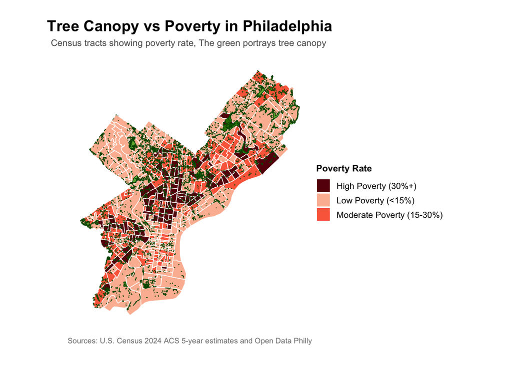

```r
#mapping

ggplot () +
  geom_sf(
    data = philly_data,
    aes(fill = poverty_category),
    color = "white",
    linewidth = .3
  ) +
  geom_sf(
    data = philly_trees_simple,
    fill = "#00aa00",
    color = "#005500",
    linewidth = .3,
    alpha = .7
  ) +
  scale_fill_manual(
    values = c(
      "High Poverty (30%+)" = "#67000d",
      "Moderate Poverty (15-30%)" = "#fb6a4a",
      "Low Poverty (<15%)" = "#fcbba1"
    ),
    name = "Poverty Rate"
  ) +
  labs(
    title = "Tree Canopy vs Poverty in Philadelphia",
    subtitle = "Census tracts showing poverty rate, The green portrays tree canopy ",
    caption = "Sources: U.S. Census 2024 ACS 5-year estimates and Open Data Philly"
  ) +
  theme_void(base_size = 12) +
  theme(
    plot.title = element_text(face = "bold", size = 15, hjust = .5,
                              margin = margin(b = 5)),
    plot.subtitle = element_text(size = 9, hjust = .5, color = "grey35",
                                 lineheight = 1.4, margin = margin(b = 10)),
    plot.caption = element_text(size = 7.5, hjust = .5, color = "grey50",
                                lineheight = 1.4, margin = margin(t = 10)),
    legend.position = "right",
    legend.title = element_text(size = 9, face = "bold"),
    legend.text = element_text(size = 8.5),
    legend.key.size = unit(.5, "cm"),
    plot.margin = margin(20, 20, 20, 20),
    plot.background = element_rect(fill = "white", color = NA)
  ) +
  guides(
    fill = guide_legend(
      override.aes = list(alpha = 1),
      order = 1
    )
  )
```

```r
ggsave(
  "map_canopy_poverty_philly.png",
  width  = 10,
  height = 9,
  dpi    = 300,
  bg     = "white")
```

**Analysis requirements:** - Clear code comments explaining each step - Appropriate CRS transformations - Summary statistics or counts - At least one map showing your findings - Brief interpretation of results (3-5 sentences)

## Finally - A few comments about your incorporation of feedback!

Take a few moments to clean up your markdown document and then write a line or two or three about how you may have incorporated feedback that you received after your first assignment.

## Submission Requirements

**What to submit:**

1. **Rendered HTML document posted to your course portfolio** with all code, outputs, maps, and text
   - Use `embed-resources: true` in YAML so it’s a single file
   - All code should run without errors
   - All maps and charts should display correctly
2. Submit the correct and working links of your assignment on Canvas